# Consumer Behavior Analysis

Elizabeth Kinuthia

2023-05-03

# Consumer Behavior Analysis

In this project, I analyzed Cyclistic’s company data in order to answer stakeholder questions. I performed EDA, statistical analysis, and created visualizations to drive decision making.

## Setting Up My Environment

I began setting up my enviroment by loading the necessary packages that I will use during my analysis.

```r
library(tidyverse)
library(lubridate)
library(skimr)
library(janitor)
```

## Preparing My Data and Environment for Analysis

I then collected my data, and loaded all the data into a dataframe. After that, I cleared up space in my environment to ensure my environment is as efficient as possible.

```r
#collect the Data
trips_05_2022 <- read_csv('202205-divvy-tripdata.csv')
trips_06_2022 <- read_csv('202206-divvy-tripdata.csv')
trips_07_2022 <- read_csv('202207-divvy-tripdata.csv')
trips_08_2022 <- read_csv('202208-divvy-tripdata.csv')
trips_09_2022 <- read_csv('202209-divvy-publictripdata.csv')
trips_10_2022 <- read_csv('202210-divvy-tripdata.csv')
trips_11_2022 <- read_csv('202211-divvy-tripdata.csv')
trips_12_2022 <- read_csv('202212-divvy-tripdata.csv')
trips_01_2023 <- read_csv('202301-divvy-tripdata.csv')
trips_02_2023 <- read_csv('202302-divvy-tripdata.csv')
trips_03_2023 <- read_csv('202303-divvy-tripdata.csv')
trips_04_2023 <- read_csv('202304-divvy-tripdata.csv')
#combine all the data into one dataframe
alltrips <- bind_rows(trips_05_2022, trips_06_2022,trips_07_2022,
                      trips_08_2022, trips_09_2022, trips_10_2022,
                      trips_11_2022, trips_12_2022, trips_01_2023,
                      trips_02_2023, trips_03_2023, trips_04_2023)

#clear up space in the environment
remove(trips_05_2022, trips_06_2022,trips_07_2022,
       trips_08_2022, trips_09_2022, trips_10_2022,
       trips_11_2022, trips_12_2022, trips_01_2023,
       trips_02_2023, trips_03_2023, trips_04_2023)

#create new dataframe to add new columns
cyclistic_df <- alltrips
```

## Data Wrangling

In this section, I performed data wrangling by transforming my data, cleaning it, and validating the data using the `skim_without_charts()` function.

### Transforming the Data

The first thing that we need to do is determine the ride length. I created a column for `ride_length`

```r
cyclistic_df$ride_length <- difftime(cyclistic_df$ended_at, cyclistic_df$started_at)
```

Another problem with our data is that it is too granular. The data can only be aggregated at a ride level, so it’s necessary to add more columns that provide additional opportunities to aggregate the data. I created columns for date, day of week, month, year, time, and hour.

```r
cyclistic_df$date <- as.Date(cyclistic_df$started_at)
cyclistic_df$day_of_week <- format(as.Date(cyclistic_df$started_at), '%A')
cyclistic_df$day <- format(as.Date(cyclistic_df$started_at), '%d')
cyclistic_df$month <- format(as.Date(cyclistic_df$started_at), '%m')
cyclistic_df$year <- format(as.Date(cyclistic_df$started_at), '%Y')
cyclistic_df$time <- format(as.Date(cyclistic_df$started_at), '%H:%M:%S')
cyclistic_df$hour <- hour(cyclistic_df$started_at)
```

I also created a column to indicate the season, i.e. Spring, Summer, Autumn, and Winter.

```r
cyclistic_df <- cyclistic_df %>% mutate(season=
                                          case_when(month == '03'~'Spring',
                                                    month == '04'~'Spring',
                                                    month == '05'~'Spring',
                                                    month == '06'~'Summer',
                                                    month == '07'~'Summer',
                                                    month == '08'~'Summer',
                                                    month == '09'~'Autumn',
                                                    month == '10'~'Autumn',
                                                    month == '11'~'Autumn',
                                                    month == '12'~'Winter',
                                                    month == '01'~'Winter',
                                                    month == '02'~'Winter'))
```

I also created a column to indicate the time of day.

```r
cyclistic_df <- cyclistic_df %>% mutate(time_of_day=
                                          case_when(hour == '0'~'Night',
                                                    hour == '1'~'Night',
                                                    hour == '2'~'Night',
                                                    hour == '3'~'Night',
                                                    hour == '4'~'Night',
                                                    hour == '5'~'Night',
                                                    hour == '6'~'Morning',
                                                    hour == '7'~'Morning',
                                                    hour == '8'~'Morning',
                                                    hour == '9'~'Morning',
                                                    hour == '10'~'Morning',
                                                    hour == '11'~'Morning',
                                                    hour == '12'~'Afternoon',
                                                    hour == '13'~'Afternoon',
                                                    hour == '14'~'Afternoon',
                                                    hour == '15'~'Afternoon',
                                                    hour == '16'~'Afternoon',
                                                    hour == '17'~'Evening',
                                                    hour == '18'~'Evening',
                                                    hour == '19'~'Evening',
                                                    hour == '20'~'Evening',
                                                    hour == '21'~'Evening',
                                                    hour == '22'~'Night',
                                                    hour == '23'~'Night'))
```

### Data Cleaning

I first used `skim_without_charts()` to check which columns had null values in them.

```r
skim_without_charts(cyclistic_df)
```

Data summary

| Name | cyclistic_df |
| --- | --- |
| Number of rows | 5859061 |
| Number of columns | 23 |
| _______________________ |  |
| Column type frequency: |  |
| character | 14 |
| Date | 1 |
| difftime | 1 |
| numeric | 5 |
| POSIXct | 2 |
| ________________________ |  |
| Group variables | None |

**Variable type: character**

| skim_variable | n_missing | complete_rate | min | max | empty | n_unique | whitespace |
| --- | --- | --- | --- | --- | --- | --- | --- |
| ride_id | 0 | 1.00 | 16 | 16 | 0 | 5859061 | 0 |
| rideable_type | 0 | 1.00 | 11 | 13 | 0 | 3 | 0 |
| start_station_name | 832009 | 0.86 | 3 | 64 | 0 | 1722 | 0 |
| start_station_id | 832141 | 0.86 | 3 | 36 | 0 | 1319 | 0 |
| end_station_name | 889661 | 0.85 | 3 | 64 | 0 | 1741 | 0 |
| end_station_id | 889802 | 0.85 | 3 | 36 | 0 | 1324 | 0 |
| member_casual | 0 | 1.00 | 6 | 6 | 0 | 2 | 0 |
| day_of_week | 0 | 1.00 | 6 | 9 | 0 | 7 | 0 |
| day | 0 | 1.00 | 2 | 2 | 0 | 31 | 0 |
| month | 0 | 1.00 | 2 | 2 | 0 | 12 | 0 |
| year | 0 | 1.00 | 4 | 4 | 0 | 2 | 0 |
| time | 0 | 1.00 | 8 | 8 | 0 | 1 | 0 |
| season | 0 | 1.00 | 6 | 6 | 0 | 4 | 0 |
| time_of_day | 0 | 1.00 | 5 | 9 | 0 | 4 | 0 |

**Variable type: Date**

| skim_variable | n_missing | complete_rate | min | max | median | n_unique |
| --- | --- | --- | --- | --- | --- | --- |
| date | 0 | 1 | 2022-05-01 | 2023-04-30 | 2022-08-28 | 365 |

**Variable type: difftime**

| skim_variable | n_missing | complete_rate | min | max | median | n_unique |
| --- | --- | --- | --- | --- | --- | --- |
| ride_length | 0 | 1 | -621201 secs | 2483235 secs | 599 secs | 22502 |

**Variable type: numeric**

| skim_variable | n_missing | complete_rate | mean | sd | p0 | p25 | p50 | p75 | p100 |
| --- | --- | --- | --- | --- | --- | --- | --- | --- | --- |
| start_lat | 0 | 1 | 41.90 | 0.05 | 41.64 | 41.88 | 41.90 | 41.93 | 42.07 |
| start_lng | 0 | 1 | -87.65 | 0.03 | -87.84 | -87.66 | -87.64 | -87.63 | -87.52 |
| end_lat | 5973 | 1 | 41.90 | 0.07 | 0.00 | 41.88 | 41.90 | 41.93 | 42.37 |
| end_lng | 5973 | 1 | -87.65 | 0.11 | -88.14 | -87.66 | -87.64 | -87.63 | 0.00 |
| hour | 0 | 1 | 14.21 | 5.02 | 0.00 | 11.00 | 15.00 | 18.00 | 23.00 |

**Variable type: POSIXct**

| skim_variable | n_missing | complete_rate | min | max | median | n_unique |
| --- | --- | --- | --- | --- | --- | --- |
| started_at | 0 | 1 | 2022-05-01 00:00:06 | 2023-04-30 23:59:05 | 2022-08-28 12:44:57 | 4916326 |
| ended_at | 0 | 1 | 2022-05-01 00:05:17 | 2023-05-03 10:37:12 | 2022-08-28 13:07:09 | 4930169 |

I then I cleaned the data by removing unnecessary columns, null values and duplicate rows.

```r
cyclistic_df <- cyclistic_df %>%
  select(-c(ride_id, start_station_id, end_station_id, start_lat, start_lng, end_lat, end_lng))

cyclistic_df <- cyclistic_df %>%
  filter(!(is.na(started_at)))

cyclistic_df <- distinct(cyclistic_df)
```

Then, I filtered out all trips with a negative value for trip duration, and the trips from start station ‘HQ QR’. This is because these bikes were taken out of circulation by Cyclistic for quality control reasons.

```r
cyclistic_df <- cyclistic_df %>%
  filter(!(start_station_name == 'HQ QR' | ride_length <0))
```

I then set the order for these columns:

1. `day_of_week` column
2. `time_of_day` column
3. `season` column

```r
#set order for day_of_week column
cyclistic_df$day_of_week <- cyclistic_df$day_of_week %>%
  ordered(levels = c('Sunday','Monday','Tuesday','Wednesday','Thursday','Friday','Saturday'))

#set order for time_of_day column
cyclistic_df$time_of_day <- cyclistic_df$time_of_day %>%
  ordered(levels = c('Morning','Afternoon','Evening','Night'))

#set order for season column
cyclistic_df$season <- cyclistic_df$season %>%
  ordered(levels = c('Winter','Spring','Summer','Autumn'))
```

Finally, I viewed my data to check the quality of the data after performing data wrangling.

```r
skim_without_charts(cyclistic_df)
```

Data summary

| Name | cyclistic_df |
| --- | --- |
| Number of rows | 5026944 |
| Number of columns | 16 |
| _______________________ |  |
| Column type frequency: |  |
| character | 8 |
| Date | 1 |
| difftime | 1 |
| factor | 3 |
| numeric | 1 |
| POSIXct | 2 |
| ________________________ |  |
| Group variables | None |

**Variable type: character**

| skim_variable | n_missing | complete_rate | min | max | empty | n_unique | whitespace |
| --- | --- | --- | --- | --- | --- | --- | --- |
| rideable_type | 0 | 1.0 | 11 | 13 | 0 | 3 | 0 |
| start_station_name | 0 | 1.0 | 3 | 64 | 0 | 1722 | 0 |
| end_station_name | 492791 | 0.9 | 3 | 64 | 0 | 1652 | 0 |
| member_casual | 0 | 1.0 | 6 | 6 | 0 | 2 | 0 |
| day | 0 | 1.0 | 2 | 2 | 0 | 31 | 0 |
| month | 0 | 1.0 | 2 | 2 | 0 | 12 | 0 |
| year | 0 | 1.0 | 4 | 4 | 0 | 2 | 0 |
| time | 0 | 1.0 | 8 | 8 | 0 | 1 | 0 |

**Variable type: Date**

| skim_variable | n_missing | complete_rate | min | max | median | n_unique |
| --- | --- | --- | --- | --- | --- | --- |
| date | 0 | 1 | 2022-05-01 | 2023-04-30 | 2022-08-27 | 365 |

**Variable type: difftime**

| skim_variable | n_missing | complete_rate | min | max | median | n_unique |
| --- | --- | --- | --- | --- | --- | --- |
| ride_length | 0 | 1 | 0 secs | 2483235 secs | 611 secs | 21810 |

**Variable type: factor**

| skim_variable | n_missing | complete_rate | ordered | n_unique | top_counts |
| --- | --- | --- | --- | --- | --- |
| day_of_week | 0 | 1 | TRUE | 7 | Sat: 787613, Thu: 753769, Wed: 724437, Fri: 721782 |
| season | 0 | 1 | TRUE | 4 | Sum: 2061565, Aut: 1350615, Spr: 1133690, Win: 481074 |
| time_of_day | 0 | 1 | TRUE | 4 | Aft: 1683370, Eve: 1668325, Mor: 1221048, Nig: 454201 |

**Variable type: numeric**

| skim_variable | n_missing | complete_rate | mean | sd | p0 | p25 | p50 | p75 | p100 |
| --- | --- | --- | --- | --- | --- | --- | --- | --- | --- |
| hour | 0 | 1 | 14.2 | 4.99 | 0 | 11 | 15 | 18 | 23 |

**Variable type: POSIXct**

| skim_variable | n_missing | complete_rate | min | max | median | n_unique |
| --- | --- | --- | --- | --- | --- | --- |
| started_at | 0 | 1 | 2022-05-01 00:00:06 | 2023-04-30 23:58:48 | 2022-08-27 13:49:56 | 4304517 |
| ended_at | 0 | 1 | 2022-05-01 00:05:17 | 2023-05-03 10:37:12 | 2022-08-27 14:16:25 | 4318878 |

## Exploratory and Statistical Data Analysis

In this phase, I performed Exploratory Data Analysis and Statistical Analysis, and used visualizations to analyze my data.

### Analyzing Total Rides

I found the total number of rides and visualized it according to user type using the `ggplot2` library.

```r
nrow(cyclistic_df)
```

```
## [1] 5026944
```

```r
cyclistic_df %>%
  group_by(member_casual) %>%
  count(member_casual)
```

```
## # A tibble: 2 × 2
## # Groups:   member_casual [2]
##   member_casual       n
##   <chr>           <int>
## 1 casual        2011919
## 2 member        3015025
```

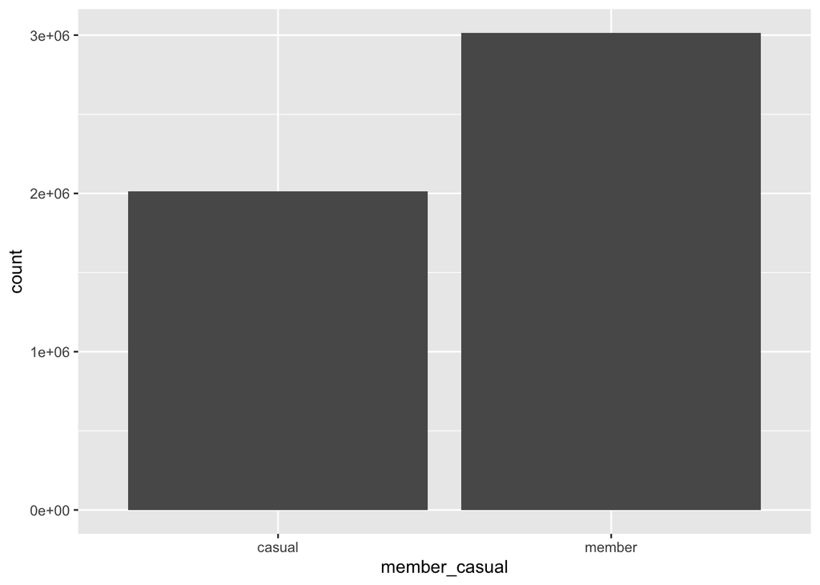

```r
cyclistic_df %>%
  ggplot() + geom_bar(aes(x=member_casual))
```

I analyzed the total rides per member type and per bike type.

```r
cyclistic_df %>%
  group_by(member_casual) %>%
  count(rideable_type)
```

```
## # A tibble: 5 × 3
## # Groups:   member_casual [2]
##   member_casual rideable_type       n
##   <chr>         <chr>           <int>
## 1 casual        classic_bike   891223
## 2 casual        docked_bike    170514
## 3 casual        electric_bike  950182
## 4 member        classic_bike  1751318
## 5 member        electric_bike 1263707
```

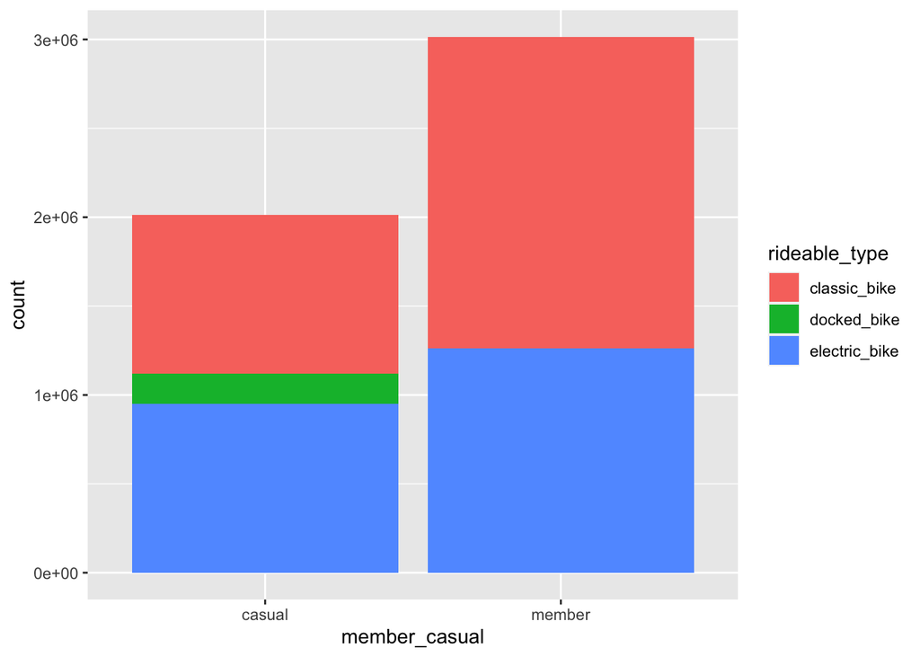

```r
cyclistic_df %>%
  ggplot() + geom_bar(aes(x=member_casual, fill=rideable_type))
```

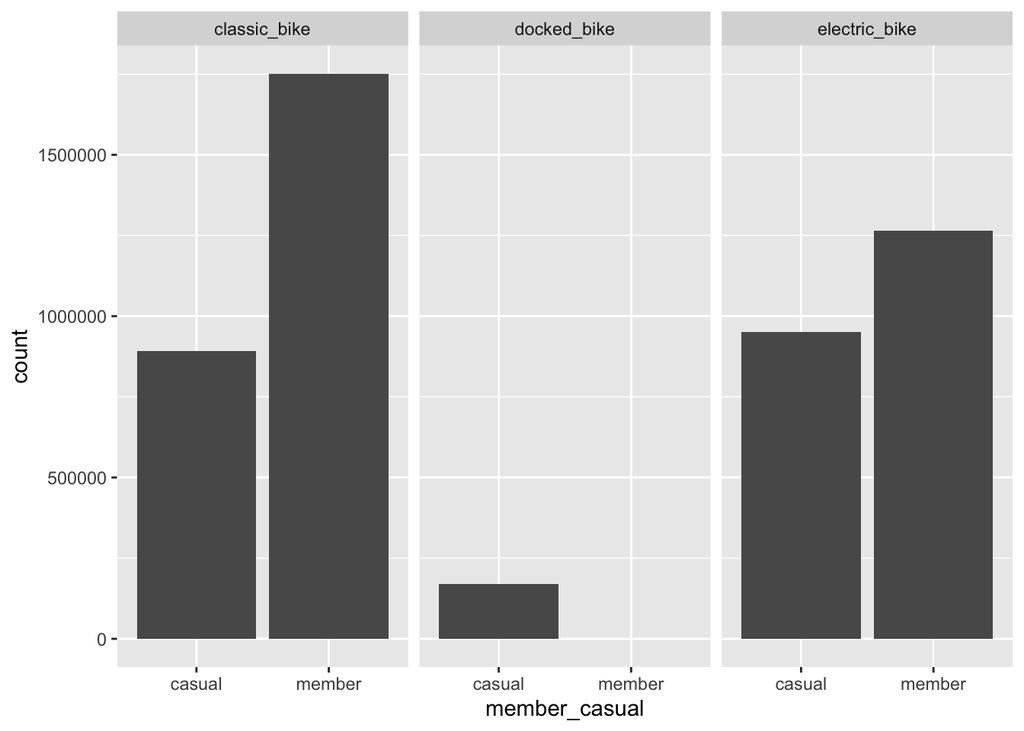

```r
cyclistic_df %>%
  ggplot() + geom_bar(aes(x=member_casual)) + facet_wrap(~rideable_type)
```

I analyzed the total rides per day of the week

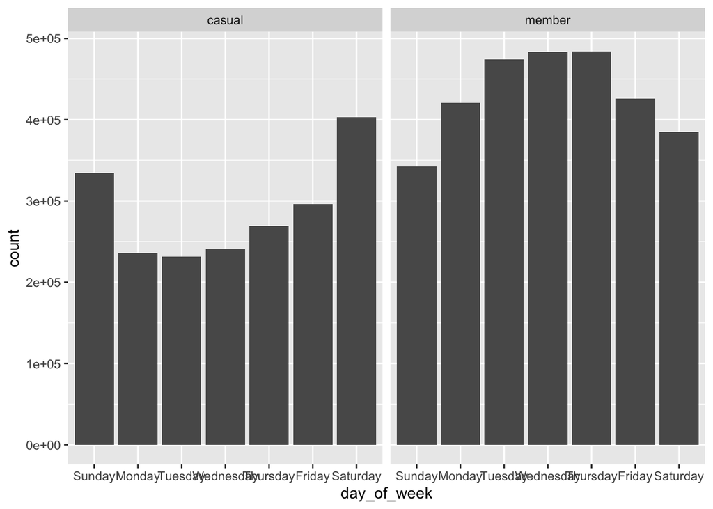

```r
cyclistic_df %>%
  ggplot() + geom_bar(aes(x=day_of_week)) + facet_wrap(~member_casual)
```

```r
cyclistic_df %>%
  group_by(day_of_week, member_casual) %>%
  count()
```

```
## # A tibble: 14 × 3
## # Groups:   day_of_week, member_casual [14]
##    day_of_week member_casual      n
##    <ord>       <chr>          <int>
##  1 Sunday      casual        334691
##  2 Sunday      member        342182
##  3 Monday      casual        235871
##  4 Monday      member        420893
##  5 Tuesday     casual        231570
##  6 Tuesday     member        474136
##  7 Wednesday   casual        241244
##  8 Wednesday   member        483193
##  9 Thursday    casual        269677
## 10 Thursday    member        484092
## 11 Friday      casual        296028
## 12 Friday      member        425754
## 13 Saturday    casual        402838
## 14 Saturday    member        384775
```

I analyzed the total rides per month

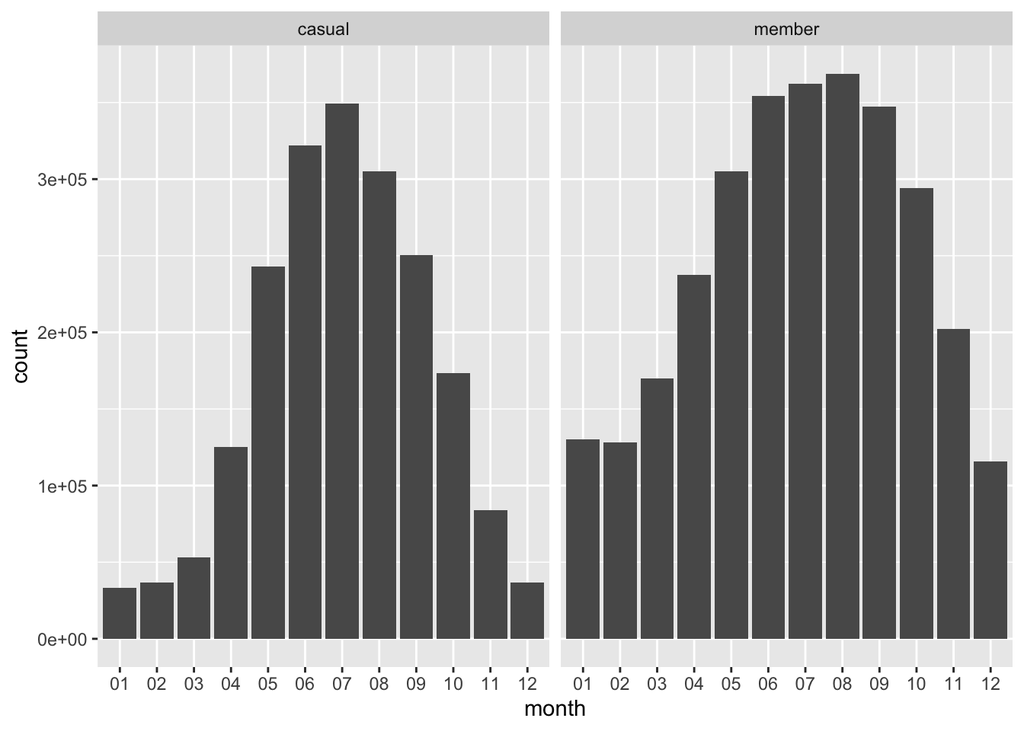

```r
cyclistic_df %>%
  ggplot() + geom_bar(aes(x=month)) + facet_wrap(~member_casual)
```

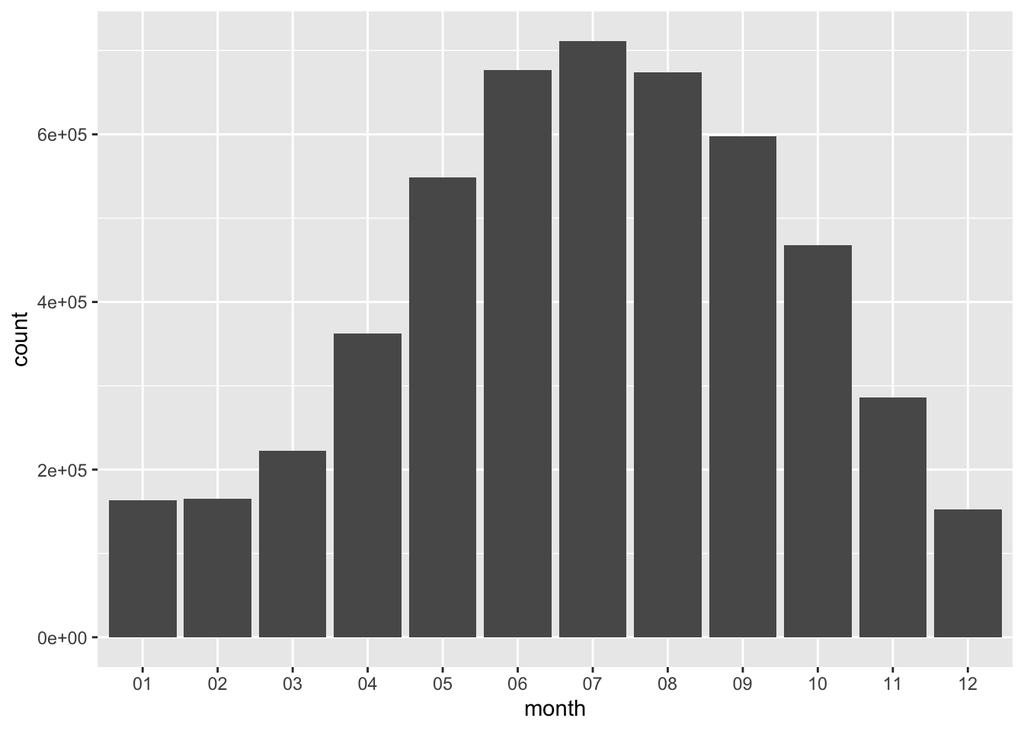

```r
cyclistic_df %>%
  ggplot() + geom_bar(aes(x=month))
```

```r
cyclistic_df %>%
  group_by(month) %>%
  count()
```

```
## # A tibble: 12 × 2
## # Groups:   month [12]
##    month      n
##    <chr>  <int>
##  1 01    163580
##  2 02    164971
##  3 03    222768
##  4 04    362771
##  5 05    548151
##  6 06    676254
##  7 07    711433
##  8 08    673878
##  9 09    597547
## 10 10    467327
## 11 11    285741
## 12 12    152523
```

I analyzed the total rides per year

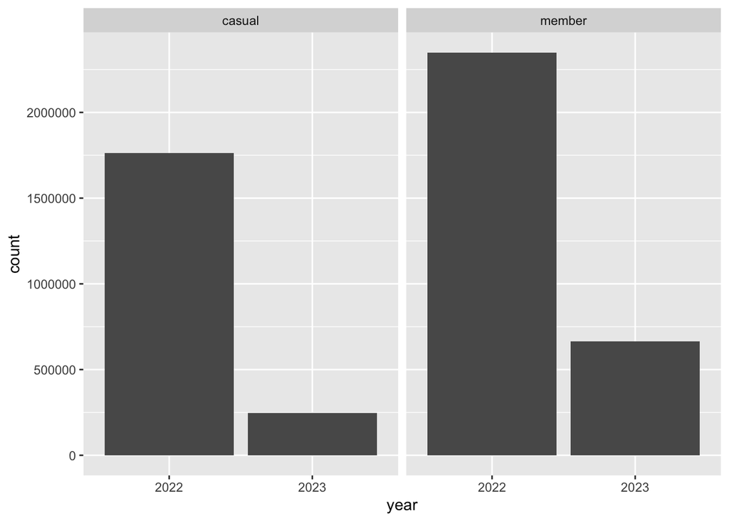

```r
cyclistic_df %>%
  ggplot() + geom_bar(aes(x=year)) + facet_wrap(~member_casual)
```

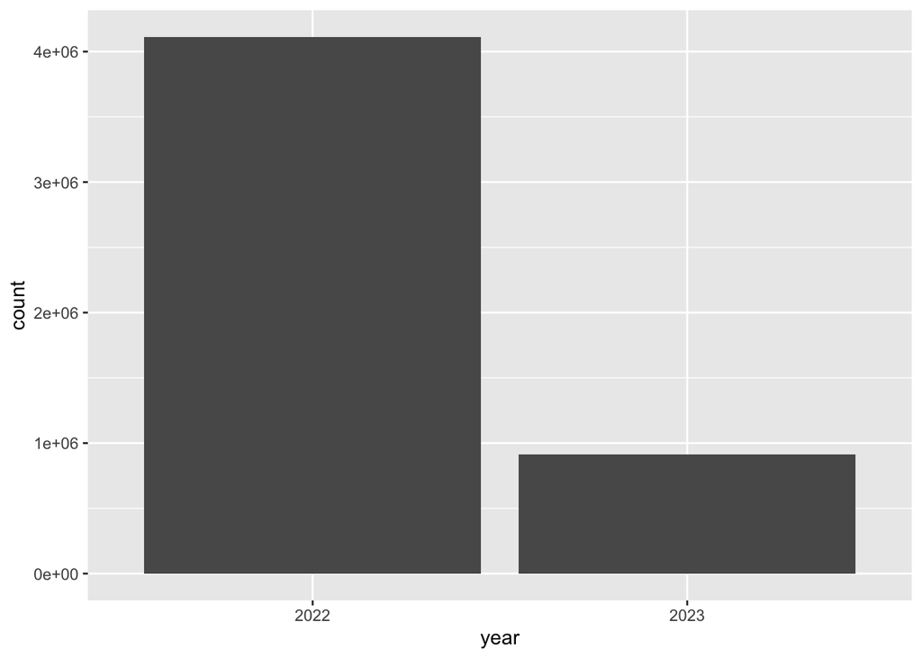

```r
cyclistic_df %>%
  ggplot() + geom_bar(aes(x=year))
```

```r
cyclistic_df %>%
  group_by(year) %>%
  count(member_casual)
```

```
## # A tibble: 4 × 3
## # Groups:   year [2]
##   year  member_casual       n
##   <chr> <chr>           <int>
## 1 2022  casual        1763755
## 2 2022  member        2349099
## 3 2023  casual         248164
## 4 2023  member         665926
```

I analyzed the total rides per season

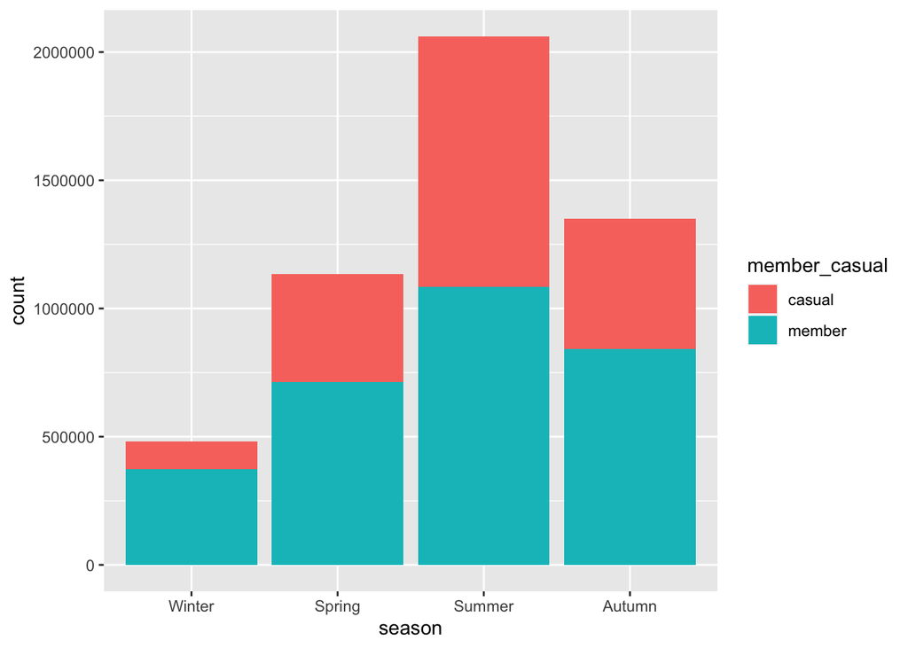

```r
cyclistic_df %>%
  ggplot() + geom_bar(aes(x=season, fill = member_casual))
```

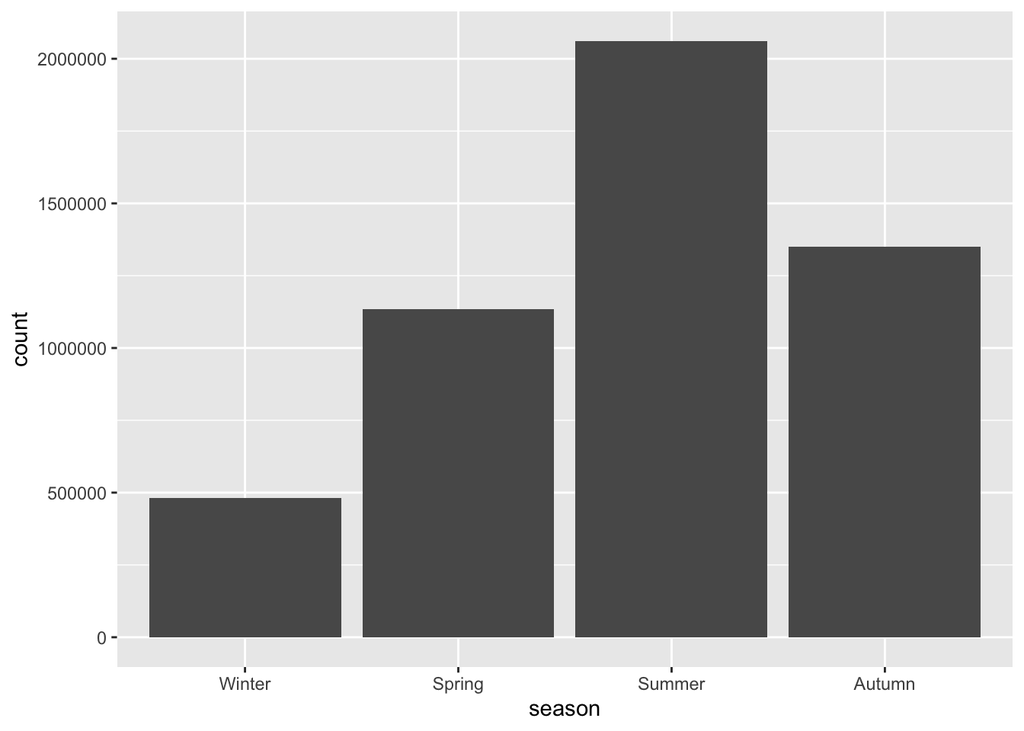

```r
cyclistic_df %>%
  ggplot() + geom_bar(aes(x=season))
```

```r
cyclistic_df %>%
  group_by(season) %>%
  count(member_casual)
```

```
## # A tibble: 8 × 3
## # Groups:   season [4]
##   season member_casual       n
##   <ord>  <chr>           <int>
## 1 Winter casual         106710
## 2 Winter member         374364
## 3 Spring casual         421142
## 4 Spring member         712548
## 5 Summer casual         976692
## 6 Summer member        1084873
## 7 Autumn casual         507375
## 8 Autumn member         843240
```

I analyzed the total rides for each time of day

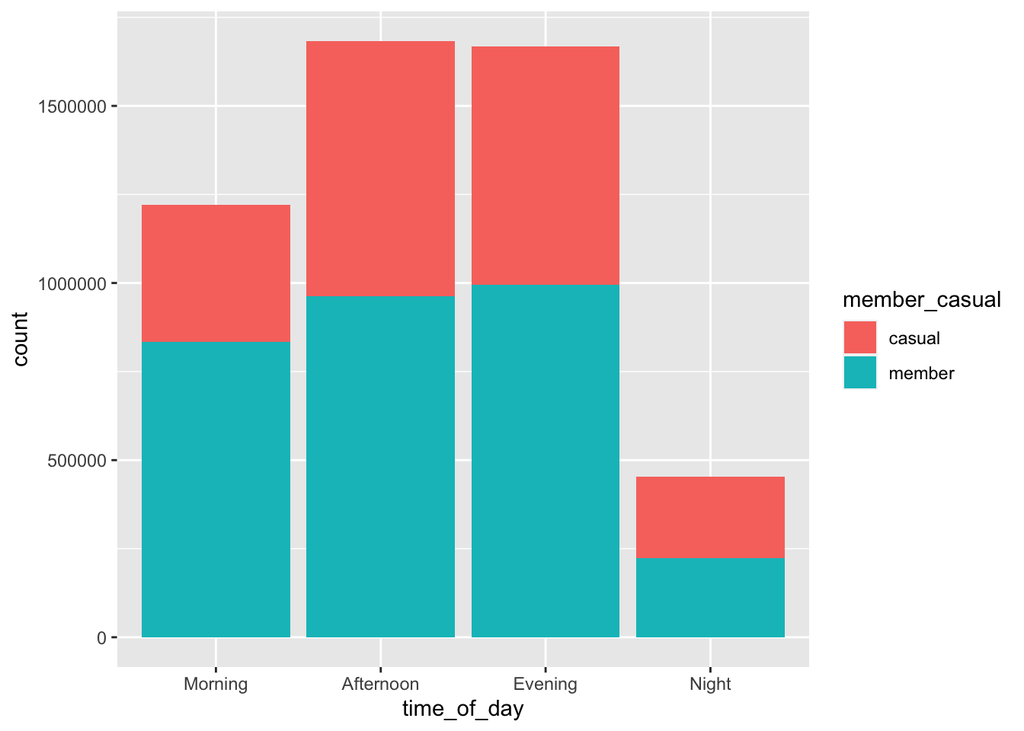

```r
cyclistic_df %>%
  ggplot() + geom_bar(aes(x=time_of_day, fill = member_casual))
```

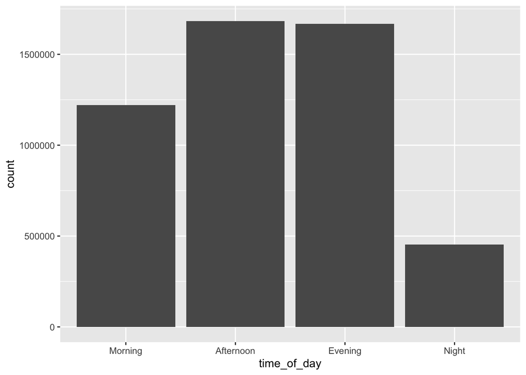

```r
cyclistic_df %>%
  ggplot() + geom_bar(aes(x=time_of_day))
```

```r
cyclistic_df %>%
  group_by(time_of_day) %>%
  count(member_casual)
```

```
## # A tibble: 8 × 3
## # Groups:   time_of_day [4]
##   time_of_day member_casual      n
##   <ord>       <chr>          <int>
## 1 Morning     casual        386363
## 2 Morning     member        834685
## 3 Afternoon   casual        721371
## 4 Afternoon   member        961999
## 5 Evening     casual        674151
## 6 Evening     member        994174
## 7 Night       casual        230034
## 8 Night       member        224167
```

I analyzed the total rides per hour

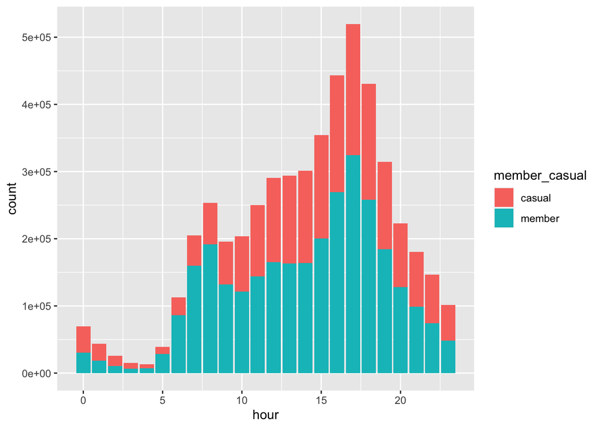

```r
cyclistic_df %>%
  ggplot() + geom_bar(aes(x=hour, fill = member_casual))
```

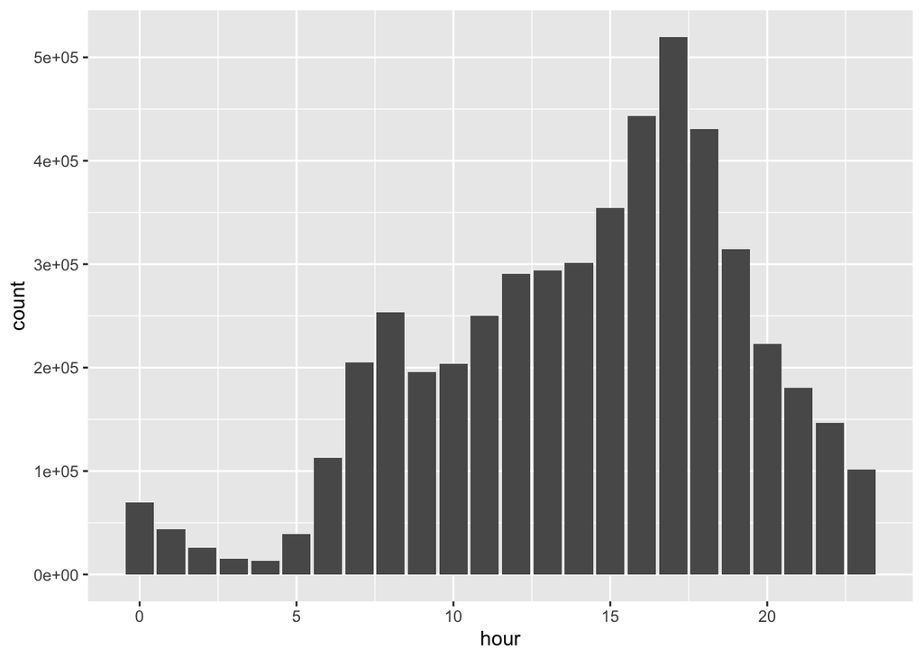

```r
cyclistic_df %>%
  ggplot() + geom_bar(aes(x=hour))
```

```r
cyclistic_df %>%
  group_by(hour) %>%
  count() %>%
  max()
```

```
## [1] 519724
```

### Analyzing Trip Length

First, I created a column to be able to analyze the trip length in minutes.

```r
cyclistic_df$ride_length_min <- difftime(cyclistic_df$ended_at, cyclistic_df$started_at, units = "mins")
```

Then I calculated the mean, and viewed the distribution of the trip length.

```r
mean(as.numeric(cyclistic_df$ride_length_min)) #average trip length in minutes
```

```
## [1] 19.9365
```

```r
summary(as.numeric(cyclistic_df$ride_length_min)) #distribution of trip length
```

```
##     Min.  1st Qu.   Median     Mean  3rd Qu.     Max.
##     0.00     5.78    10.18    19.94    18.32 41387.25
```

I analyzed the average trip length per user type.

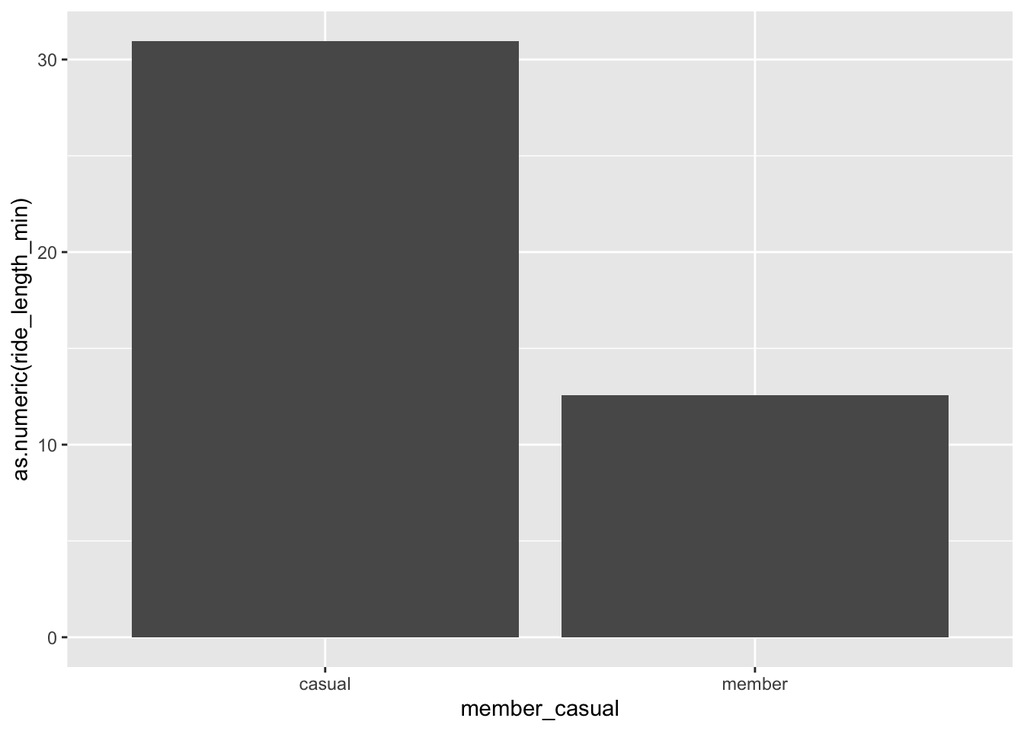

```r
cyclistic_df %>%
  ggplot(aes(x=member_casual, y=as.numeric(ride_length_min))) + geom_bar(stat = "summary",fun="mean")
```

```r
cyclistic_df %>%
  group_by(member_casual) %>%
  summarise(mean_ride_length = mean(ride_length_min)) %>%
  as.data.frame()
```

```
##   member_casual mean_ride_length
## 1        casual    30.96399 mins
## 2        member    12.57789 mins
```

I analyzed the average trip length per bike type.

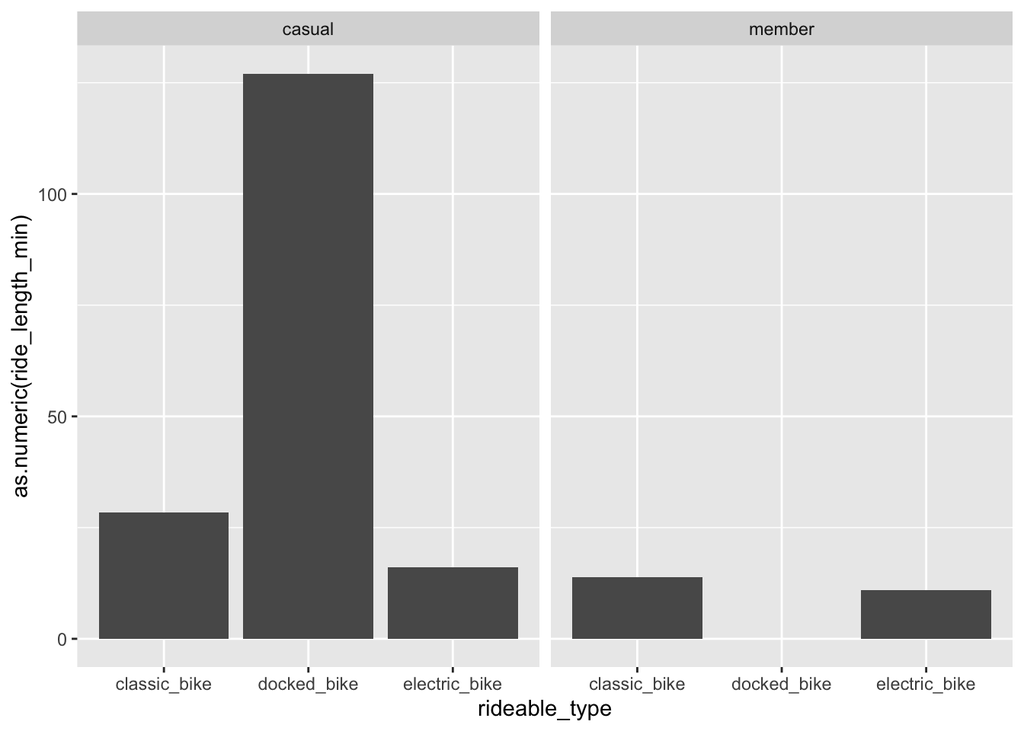

```r
cyclistic_df %>%
  ggplot(aes(x=rideable_type, y=as.numeric(ride_length_min))) +
  geom_bar(stat = "summary",fun="mean") +
  facet_wrap(~member_casual)
```

```r
cyclistic_df %>%
  group_by(rideable_type, member_casual) %>%
  summarise(mean_ride_length = mean(ride_length_min)) %>%
  as.data.frame()
```

```
##   rideable_type member_casual mean_ride_length
## 1  classic_bike        casual    28.37995 mins
## 2  classic_bike        member    13.76752 mins
## 3   docked_bike        casual   127.02033 mins
## 4 electric_bike        casual    16.14999 mins
## 5 electric_bike        member    10.92922 mins
```

I analyzed the average trip length per month.

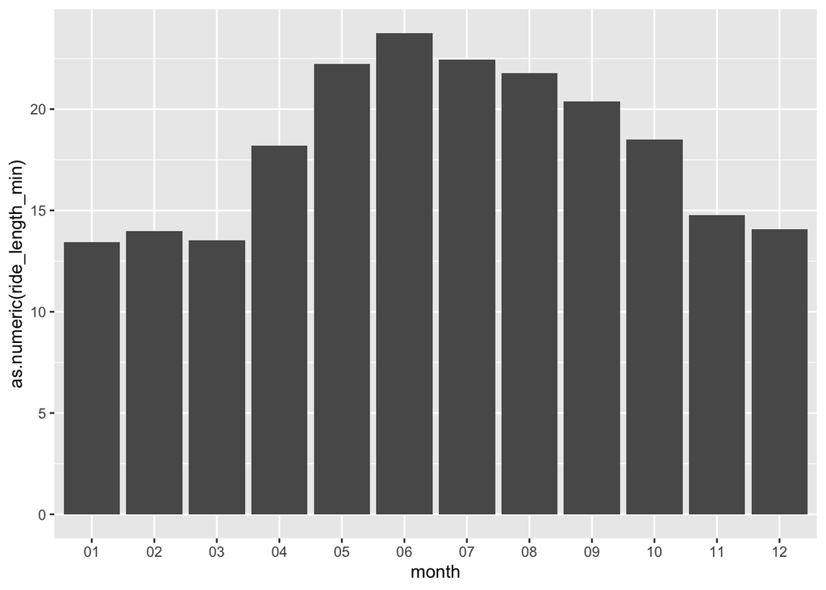

```r
cyclistic_df %>%
  ggplot(aes(x=month, y=as.numeric(ride_length_min))) + geom_bar(stat = "summary",fun="mean")
```

```r
cyclistic_df %>%
  group_by(month) %>%
  summarise(mean_ride_length = mean(ride_length_min)) %>%
  as.data.frame()
```

```
##    month mean_ride_length
## 1     01    13.43883 mins
## 2     02    13.96931 mins
## 3     03    13.53031 mins
## 4     04    18.20735 mins
## 5     05    22.23611 mins
## 6     06    23.75599 mins
## 7     07    22.44529 mins
## 8     08    21.79145 mins
## 9     09    20.37648 mins
## 10    10    18.49703 mins
## 11    11    14.78127 mins
## 12    12    14.07651 mins
```

I analyzed the average trip length per year.

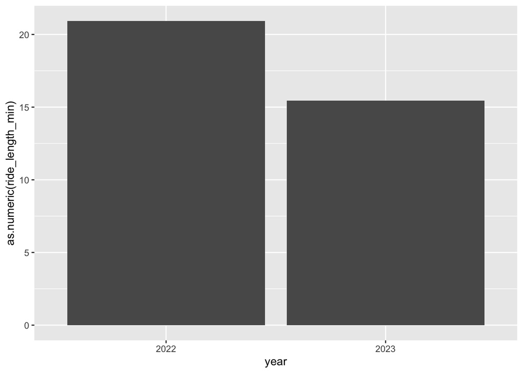

```r
cyclistic_df %>%
  ggplot(aes(x=year, y=as.numeric(ride_length_min))) + geom_bar(stat = "summary",fun="mean")
```

```r
cyclistic_df %>%
  group_by(year) %>%
  summarise(mean_ride_length = mean(ride_length_min)) %>%
  as.data.frame()
```

```
##   year mean_ride_length
## 1 2022    20.93379 mins
## 2 2023    15.44933 mins
```

I analyzed the average trip length per season.

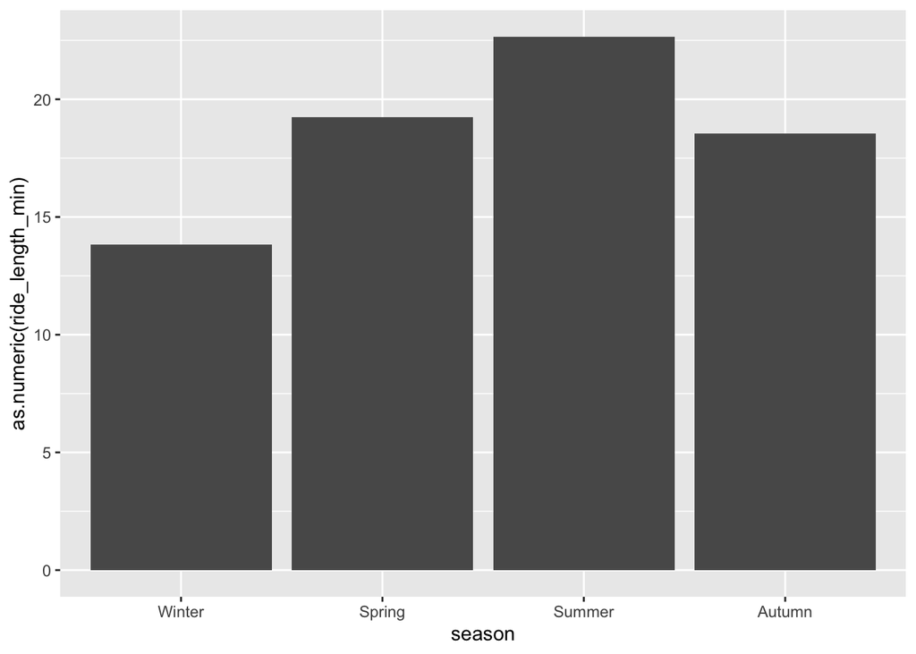

```r
cyclistic_df %>%
  ggplot(aes(x=season, y=as.numeric(ride_length_min))) + geom_bar(stat = "summary",fun="mean")
```

```r
cyclistic_df %>%
  group_by(season) %>%
  summarise(mean_ride_length = mean(ride_length_min)) %>%
  as.data.frame()
```

```
##   season mean_ride_length
## 1 Winter    13.82292 mins
## 2 Spring    19.23627 mins
## 3 Summer    22.66151 mins
## 4 Autumn    18.54243 mins
```

I analyzed the average trip length for each time of day.

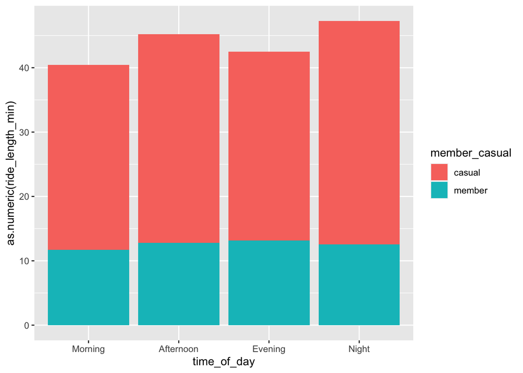

```r
cyclistic_df %>%
  ggplot(aes(x=time_of_day, y=as.numeric(ride_length_min),fill=member_casual)) +
  geom_bar(stat = "summary",fun="mean")
```

```r
cyclistic_df %>%
  group_by(time_of_day,member_casual) %>%
  summarise(mean_ride_length = mean(ride_length_min)) %>%
  as.data.frame()
```

```
##   time_of_day member_casual mean_ride_length
## 1     Morning        casual    28.72115 mins
## 2     Morning        member    11.70949 mins
## 3   Afternoon        casual    32.44069 mins
## 4   Afternoon        member    12.77020 mins
## 5     Evening        casual    29.38489 mins
## 6     Evening        member    13.12712 mins
## 7       Night        casual    34.72804 mins
## 8       Night        member    12.55021 mins
```

I analyzed the average trip length per hour.

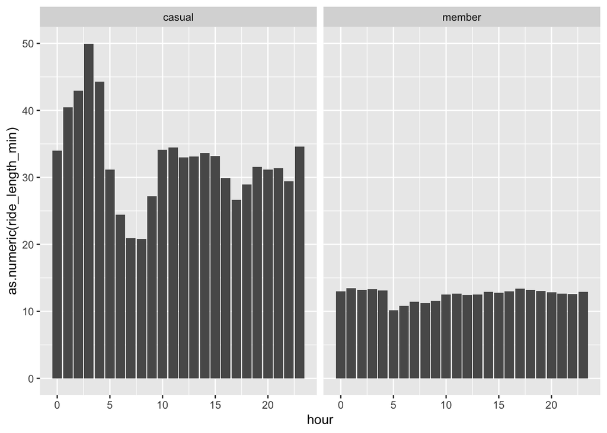

```r
cyclistic_df %>%
  ggplot(aes(x=hour, y=as.numeric(ride_length_min))) +
  geom_bar(stat = "summary",fun="mean") +
  facet_wrap(~member_casual)
```

```r
cyclistic_df %>%
  group_by(hour,member_casual) %>%
  summarise(mean_ride_length = mean(ride_length_min)) %>%
  as.data.frame()
```

```
##    hour member_casual mean_ride_length
## 1     0        casual    33.99022 mins
## 2     0        member    12.97354 mins
## 3     1        casual    40.47772 mins
## 4     1        member    13.45973 mins
## 5     2        casual    42.95581 mins
## 6     2        member    13.18720 mins
## 7     3        casual    49.95563 mins
## 8     3        member    13.31058 mins
## 9     4        casual    44.30282 mins
## 10    4        member    13.13446 mins
## 11    5        casual    31.13096 mins
## 12    5        member    10.18403 mins
## 13    6        casual    24.42277 mins
## 14    6        member    10.84246 mins
```

[output cut: 34 more lines]

```r
cyclistic_df %>%
  group_by(hour) %>%
  summarise(mean_ride_length = mean(as.numeric(ride_length_min))) %>%
  as.data.frame() %>% max()
```

```
## [1] 34.31898
```

After I had performed my analysis I was able to gain the following insights:

1. Even though annual members took the most bike rides, casual riders rode their bikes for longer periods of time each ride.

```
* Casual riders took their longest bike rides at night.
```

2. The classic bike was the most popular bike among annual members, while the electric bike was most popular among casual riders.

```
* Casual riders rode the longest on the docked bikes, even though docked bikes had the least amount of rides total.
```

3. Casual riders prefer to ride their bikes on weekends, where as annual members ride their bikes most during weekdays.
4. Summer was the most popular season for bike riding for both annual and casual riders.

## Data Visualization Preparation

Now that the analysis was complete, I prepared the data for visualization in Tableau.

```r
cyclistic_viz <- cyclistic_df
cyclistic_viz <- cyclistic_viz %>% mutate(month =
                                                case_when(month == '01'~'January',
                                                          month == '02'~'February',
                                                          month == '03'~'March',
                                                          month == '04'~'April',
                                                          month == '05'~'May',
                                                          month == '06'~'June',
                                                          month == '07'~'July',
                                                          month == '08'~'August',
                                                          month == '09'~'September',
                                                          month == '10'~'October',
                                                          month == '11'~'November',
                                                          month == '12'~'December'))
```

I made sure to set the order for the month column.

```r
cyclistic_viz$month <- cyclistic_viz$month %>%
  ordered(levels = c('January','February','March','April','May','June','July',
                     'August','September','October','November','December'))
```

I then exported my data to a csv file. With that, my analysis using R programming was complete.

```r
library(data.table)
```

```r
fwrite(cyclistic_viz,'cyclistic_tableau_data.csv')
```